# Sentiment Analysis of Environmental News

Marc Los Huertos

EA030 · Compiled 2026-05-10

EA030 — Activity A29

# Sentiment Analysis of Environmental News

**Prof. Marc Los Huertos** • Pomona College • EA030 Environmental Analysis

← Back to Activities

Why Sentiment? Methods Landscape Building a Corpus Lexicon Scoring Aspect-Based Transformers Time Series Validation Full Pipeline Energy News Example Extensions

#### 🎯 Learning Outcomes

1. Explain what sentiment analysis measures and why it matters for environmental research.
2. Build a text corpus from news articles using `quanteda` and `readtext`.
3. Apply dictionary-based sentiment scoring with LSD2015, AFINN, and NRC lexicons.
4. Handle valence shifters (negation, amplifiers) with `sentimentr`.
5. Perform aspect-based sentiment analysis toward specific entities or topics.
6. Call pre-trained transformer models (ClimateBERT) from R using the `text` package.
7. Aggregate document-level sentiment into time-series indices with `sentometrics`.
8. Validate sentiment models against hand-coded labels using Cohen’s kappa and macro-F1.
9. Recognize the limitations of each approach and choose the right tool for a given research question.
10. Compare three lexicon approaches head-to-head and evaluate which best correlates with an external variable (energy commodity prices).

> **What this module covers.** How do news outlets portray environmental issues over time? Is coverage of climate policy becoming more or less alarmist? Do articles about renewable energy carry a different tone than articles about fossil fuels? These are **sentiment analysis** questions, and answering them requires converting unstructured text into structured quantitative measures of tone, emotion, or polarity. This tutorial walks the complete R workflow, from raw text through validated time-series indices, using methods appropriate for environmental and climate-related news.

## 1. Why Sentiment Analysis for Environmental News?

Environmental scientists increasingly study not just physical systems but the **human dimensions** of environmental change: public perception, media framing, policy discourse, and stakeholder attitudes. News coverage shapes public opinion and policy priorities, so measuring its tone systematically is a legitimate research question.

Sentiment analysis converts text into numbers that represent **polarity** (positive/negative/neutral), **emotion** (anger, fear, joy, trust), or **stance** (opportunity vs. risk). Applied to a corpus of news articles, it lets you ask quantitative questions about qualitative data.

### Three motivating questions

These examples illustrate the kinds of research questions sentiment analysis can address in environmental science:

**1. Tone over time.** Has US newspaper coverage of wildfire become more negative over the past two decades? If so, does the shift correlate with increases in burned acreage, or does media framing lead or lag the physical trend?

**2. Entity-level framing.** Within a single article about the Inflation Reduction Act, is the tone toward the EPA positive while the tone toward the fossil-fuel industry is negative? A single “article-level” sentiment score would miss this entirely.

**3. Cross-outlet comparison.** Do articles from a regional paper in a coal-dependent community frame energy transition differently than articles from a national outlet? Comparing sentiment distributions across sources reveals structural differences in coverage.

**💡 Sentiment is a noisy signal, not ground truth** A sentiment score is a simplified, often imperfect measure of a complex property. News articles are written in a deliberately neutral register. Reporters attribute opinions to sources (“Critics called it a failure”) without endorsing them. Lexicon-based methods cannot distinguish the reporter’s voice from a quoted critic’s voice. Keep this in mind throughout the tutorial: every sentiment number you produce is a proxy, and the quality of that proxy must be validated.

### What sentiment analysis is not

Sentiment analysis does **not** tell you what a reader thinks, feels, or believes. It tells you something about the language in the text itself, as measured by a particular dictionary or model. Conflating text-level polarity with audience reception is a common analytical error.

It also does not handle **framing** well. Two articles can have identical sentiment scores while framing the same issue in completely different ways (economic growth vs. ecological collapse). Frame analysis requires different tools, though sentiment can serve as one input.

## 2. The Methods Landscape

Sentiment analysis methods fall into three broad families. Each trades off transparency, accuracy, and computational cost differently.

Three families of sentiment analysis methods, compared on attributes relevant to environmental news projects.

| Family | Approach | Typical Accuracy | GPU? | Labeled Data | R Packages |
| --- | --- | --- | --- | --- | --- |
| Dictionary / Lexicon | Score words against a pre-built list of polarity values. Sum or average. | Low to moderate (27-65% on multi-class news) | No | None required | quanteda, tidytext, sentimentr, sentometrics |
| Traditional ML | Train a classifier (logistic regression, SVM, random forest) on TF-IDF features with labeled data. | Moderate (58-71% on multi-class news) | No | 1,000-10,000 | tidymodels, caret, text2vec |
| Transformers & LLMs | Fine-tune a pre-trained language model (BERT, RoBERTa, ClimateBERT) on labeled examples. | High (73-84% on multi-class news) | Recommended | 500-5,000 | text (HuggingFace bridge) |

The accuracy numbers in the table come from a 2024 study (Wang et al., *Soft Computing*) that compared all three families on 9,382 news articles about transboundary rivers, scored on a 5-class scale. AFINN scored 27.4% accuracy, the best traditional ML models clustered around 66-71%, and BERT reached 72.7%. On a simpler 3-class task, domain-adapted transformers like ClimateBERT report weighted F1 scores around 0.84.

**⚠️ No public benchmark exists for environmental news specifically** ClimateBERT’s 0.84 F1 was measured on paragraphs from corporate climate disclosures, not news articles. The Wang et al. numbers are the closest rigorous head-to-head on actual news. When you report results from your own analysis, be explicit about what corpus and what labels your accuracy is measured against.

### When to use which method

The decision depends on your sample size, research question, and computational resources:

| If… | Use this |
| --- | --- |
| Corpus < 1,000 articles, exploratory | `tidytext` + AFINN / Bing / NRC |
| Need defensible news-specific baseline | `quanteda` + LSD2015 + `sentimentr` |
| Need time-series indices for regression | `sentometrics` |
| Need entity-level sentiment, no GPU | `quanteda` targeted dictionary with +/- 10-word window |
| Need accuracy > ~0.70 macro-F1 | `text` package calling ClimateBERT or cardiffnlp RoBERTa |
| Ambiguous edge cases, sarcasm | LLM (Claude, GPT-4o) zero-shot or few-shot via API |

Stage 0

Corpus Assembly

Stage 1

Lexicon Baseline

Stage 2

Transformer Layer

Stage 3

Validation

Stage 4

Time Series

This tutorial follows the pipeline above. We start with the simplest methods (lexicons) and add complexity only when needed.

## 3. Building a Corpus

Before scoring sentiment, you need a structured collection of texts with metadata. In `quanteda`, this is called a **corpus**.

### Simulated environmental news corpus

For this tutorial, we create a small simulated corpus of environmental news headlines and lead paragraphs. In a real project, you would import text from files, a database, or an API.

```r
# ── Simulated environmental news articles ──────────────────────────────
articles <- tibble(
  doc_id = paste0("art_", sprintf("%03d", 1:20)),
  source = rep(c("National Tribune", "Valley Gazette",
                 "Coastal Herald", "Mountain Post"), each = 5),
  date   = seq(as.Date("2024-01-15"), by = "month", length.out = 20),
  topic  = rep(c("wildfire", "water", "energy", "biodiversity", "climate"),
               times = 4),
  text   = c(
    # National Tribune
    "Devastating wildfire season scorches 2.3 million acres across the West, forcing thousands of evacuations and overwhelming firefighting resources.",
    "New EPA water quality standards will impose stricter limits on agricultural runoff, drawing praise from conservation groups and criticism from farm lobbies.",
    "Solar installations surged 42% in 2023, marking a record year for clean energy deployment and creating thousands of new jobs in underserved communities.",
    "Alarming decline in migratory bird populations raises concerns about habitat loss and pesticide exposure across major flyways.",
    "Global temperatures shattered records for the twelfth consecutive month, intensifying calls for accelerated emissions reductions at the upcoming climate summit.",
    # Valley Gazette
    "Local ranchers struggle to balance wildfire risk with grazing traditions as prescribed burn programs expand into private lands.",
    "Community groups celebrate the restoration of riparian habitat along Bear Creek after years of advocacy and volunteer effort.",
    "The proposed wind farm faces opposition from residents concerned about noise, visual impact, and declining property values in the rural township.",
    "Native plant restoration project transforms abandoned lot into thriving pollinator garden, attracting dozens of butterfly species.",
    "Farmers report shorter growing seasons and unpredictable frost dates, attributing the changes to shifting climate patterns.",
    # Coastal Herald
    "After years of devastating fire seasons, a coalition of agencies unveils a bold new strategy for community wildfire preparedness and resilient landscapes.",
    "Toxic algal bloom shuts down water intake for coastal city, exposing vulnerabilities in aging infrastructure and nutrient management.",
    "Offshore wind project receives final permits after environmental review finds minimal impact on marine mammals and seabirds.",
    "Kelp forest recovery surprises scientists as urchin removal program shows rapid regrowth of canopy and return of marine biodiversity.",
    "Sea level projections released today paint a stark picture for low-lying neighborhoods, with managed retreat now part of the planning conversation.",
    # Mountain Post
    "Controlled burns reduce fuel loads but spark air quality warnings in mountain communities already burdened by summer smoke.",
    "Drought emergency declared as reservoir levels drop below 30% capacity, triggering mandatory conservation measures for the first time in a decade.",
    "Utility announces early retirement of its last coal plant, pledging to replace capacity with battery storage and community solar.",
    "Endangered species listing for mountain caribou prompts heated debate between conservation advocates and logging industry representatives.",
    "Glaciers in the range have lost 40% of their volume since 1980, according to a university survey released this week."
  )
)

# Build a quanteda corpus with document-level variables
corp <- corpus(articles, text_field = "text",
               docid_field = "doc_id")
```

```r
# Quick look at the corpus
summary(corp, n = 5)
```

```
#> Corpus consisting of 20 documents, showing 5 documents:
#>
#>     Text Types Tokens Sentences           source       date        topic
#>  art_001    20     20         1 National Tribune 2024-01-15     wildfire
#>  art_002    23     24         1 National Tribune 2024-02-15        water
#>  art_003    25     26         1 National Tribune 2024-03-15       energy
#>  art_004    18     18         1 National Tribune 2024-04-15 biodiversity
#>  art_005    20     22         1 National Tribune 2024-05-15      climate
```

**💡 Document variables carry your metadata through the pipeline** The `source`, `date`, and `topic` columns you include at corpus creation travel with every token, dfm, and sentiment score downstream. This is what allows you to compare sentiment by newspaper, plot it over time, or break it out by topic later. Always attach metadata at the corpus stage, not after scoring.

### Tokenization and document-feature matrix

Most `quanteda` operations require tokenizing the corpus (splitting text into words) and converting it to a **document-feature matrix** (dfm), where rows are documents and columns are unique word types.

```r
# Tokenize: lowercase, remove punctuation and stopwords
toks <- tokens(corp,
               remove_punct  = TRUE,
               remove_numbers = TRUE) %>%
  tokens_tolower() %>%
  tokens_remove(stopwords("en"))

# Document-feature matrix
dfm_articles <- dfm(toks)
dfm_articles
```

```
#> Document-feature matrix of: 20 documents, 253 features (94.39% sparse) and 3 docvars.
#>          features
#> docs      devastating wildfire season scorches million acres across west
#>   art_001           1        1      1        1       1     1      1    1
#>   art_002           0        0      0        0       0     0      0    0
#>   art_003           0        0      0        0       0     0      0    0
#>   art_004           0        0      0        0       0     0      1    0
#>   art_005           0        0      0        0       0     0      0    0
#>   art_006           0        1      0        0       0     0      0    0
#>          features
#> docs      forcing thousands
#>   art_001       1         1
#>   art_002       0         0
#>   art_003       0         1
#>   art_004       0         0
#>   art_005       0         0
#>   art_006       0         0
#> [ reached max_ndoc ... 14 more documents, reached max_nfeat ... 243 more features ]
```

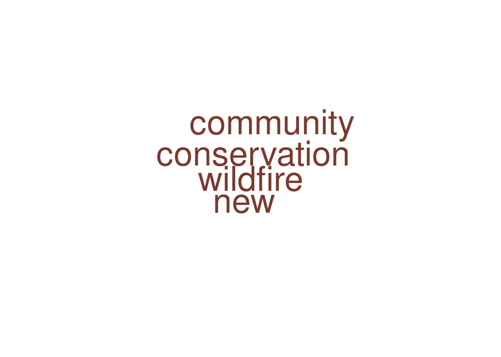

```r
set.seed(42)
textplot_wordcloud(dfm_articles, max_words = 80,
                   color = c("#1e3a2f", "#4a7c5e", "#8aad96",
                             "#c8832a", "#7a3a2f"))
```

## 4. Dictionary-Based Sentiment Scoring

The simplest approach to sentiment analysis is to look up each word in a **sentiment dictionary** (also called a lexicon) that assigns a polarity or emotion score to known words. The document’s sentiment is the sum or average of its word scores.

### Available dictionaries in R

Several dictionaries are available through different R packages. Each was built for a different purpose.

Major sentiment dictionaries available in R.

| Dictionary | Vocabulary | Scale | Best For | R Package |
| --- | --- | --- | --- | --- |
| LSD2015 | 4,567 + negation patterns | Positive / negative | News and political text | quanteda (built-in) |
| AFINN | 2,477 | -5 to +5 | Quick exploratory scoring | tidytext |
| Bing | 6,786 | Binary +/- | Simple positive/negative counts | tidytext |
| NRC | ~14,000 | 8 emotions + +/- | Emotion decomposition | tidytext, lexicon |
| Loughran-McDonald | ~4,200 | 6 categories | Financial / regulatory text | lexicon, quanteda.sentiment |
| VADER | ~7,500 | Compound [-1, +1] | Social media and headlines | sentimentr (VADER-like) |

**⚠️ Different lexicons can give opposite answers** A tutorial analysis applying four standard lexicons (AFINN, Bing, Jockers, NRC) to the same 4,508 sentences found Fleiss’ kappa of only 0.22 across the four methods. That is barely above chance agreement. Always run at least two lexicons and compare results. If they disagree, that tells you something important about the robustness of your findings.

### Scoring with LSD2015 (recommended for news)

The **Lexicoder Sentiment Dictionary** (LSD2015) was designed specifically for political and news text. It includes negation-aware word patterns (e.g., “not good” is captured as negative). It is built into `quanteda` as `data_dictionary_LSD2015`.

```r
# Apply LSD2015 dictionary to the dfm
dfm_sent <- dfm_lookup(dfm_articles,
                        dictionary = data_dictionary_LSD2015)

# Convert to a tidy data frame
lsd_scores <- convert(dfm_sent, to = "data.frame") %>%
  rename(doc_id = doc_id) %>%
  mutate(
    net_sentiment = positive - negative,
    total_words   = ntoken(corp),
    sent_ratio    = net_sentiment / total_words
  ) %>%
  bind_cols(docvars(corp))

head(lsd_scores)
```

```
#>    doc_id negative positive neg_positive neg_negative net_sentiment total_words
#> 1 art_001        3        1            0            0            -2          20
#> 2 art_002        3        3            0            0             0          24
#> 3 art_003        0        2            0            0             2          26
#> 4 art_004        3        0            0            0            -3          18
#> 5 art_005        1        0            0            0            -1          22
#> 6 art_006        3        1            0            0            -2          19
#>    sent_ratio           source       date        topic
#> 1 -0.10000000 National Tribune 2024-01-15     wildfire
#> 2  0.00000000 National Tribune 2024-02-15        water
#> 3  0.07692308 National Tribune 2024-03-15       energy
#> 4 -0.16666667 National Tribune 2024-04-15 biodiversity
#> 5 -0.04545455 National Tribune 2024-05-15      climate
#> 6 -0.10526316   Valley Gazette 2024-06-15     wildfire
```

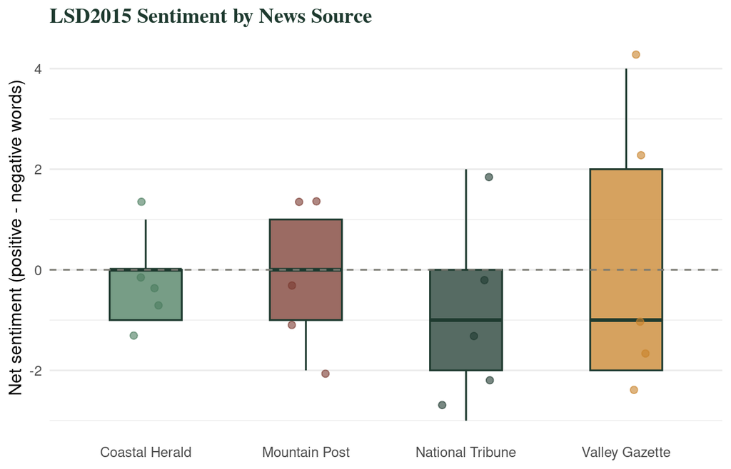

Net LSD2015 sentiment (positive minus negative word counts) by news source. Each point is one article; the dashed line at zero separates net-positive from net-negative.

```r
ggplot(lsd_scores, aes(x = source, y = net_sentiment, fill = source)) +
  geom_boxplot(width = 0.45, outlier.shape = NA,
               colour = "#1e3a2f", alpha = 0.75, linewidth = 0.6) +
  geom_jitter(aes(colour = source), width = 0.15,
              size = 2, alpha = 0.6) +
  geom_hline(yintercept = 0, linetype = "dashed", colour = "#7a7a72") +
  scale_fill_manual(values = c(
    "Coastal Herald"     = "#4a7c5e",
    "Mountain Post"      = "#7a3a2f",
    "National Tribune"   = "#1e3a2f",
    "Valley Gazette"     = "#c8832a"
  )) +
  scale_colour_manual(values = c(
    "Coastal Herald"     = "#4a7c5e",
    "Mountain Post"      = "#7a3a2f",
    "National Tribune"   = "#1e3a2f",
    "Valley Gazette"     = "#c8832a"
  )) +
  labs(x = NULL, y = "Net sentiment (positive - negative words)",
       title = "LSD2015 Sentiment by News Source") +
  theme_minimal(base_size = 12) +
  theme(
    plot.title         = element_text(family = "serif", face = "bold",
                                      colour = "#1e3a2f"),
    legend.position    = "none",
    panel.grid.major.x = element_blank()
  )
```

### Scoring with tidytext and multiple lexicons

The `tidytext` package provides access to AFINN, Bing, and NRC lexicons through a tidy one-word-per-row workflow. Running multiple lexicons in parallel is the best way to check whether your findings are robust to dictionary choice.

```r
# Tidy tokenization
tidy_articles <- articles %>%
  unnest_tokens(word, text)

# Score with AFINN
afinn_scores <- tidy_articles %>%
  inner_join(get_sentiments("afinn"), by = "word") %>%
  group_by(doc_id, source, date, topic) %>%
  summarize(
    afinn_mean = mean(value),
    afinn_sum  = sum(value),
    n_scored   = n(),
    .groups = "drop"
  )

# Score with Bing
bing_scores <- tidy_articles %>%
  inner_join(get_sentiments("bing"), by = "word") %>%
  count(doc_id, source, date, topic, sentiment) %>%
  pivot_wider(names_from = sentiment, values_from = n, values_fill = 0) %>%
  mutate(bing_net = positive - negative)

# Score with NRC (emotion categories)
nrc_emotions <- tidy_articles %>%
  inner_join(get_sentiments("nrc"), by = "word") %>%
  count(doc_id, source, topic, sentiment) %>%
  pivot_wider(names_from = sentiment, values_from = n, values_fill = 0)
```

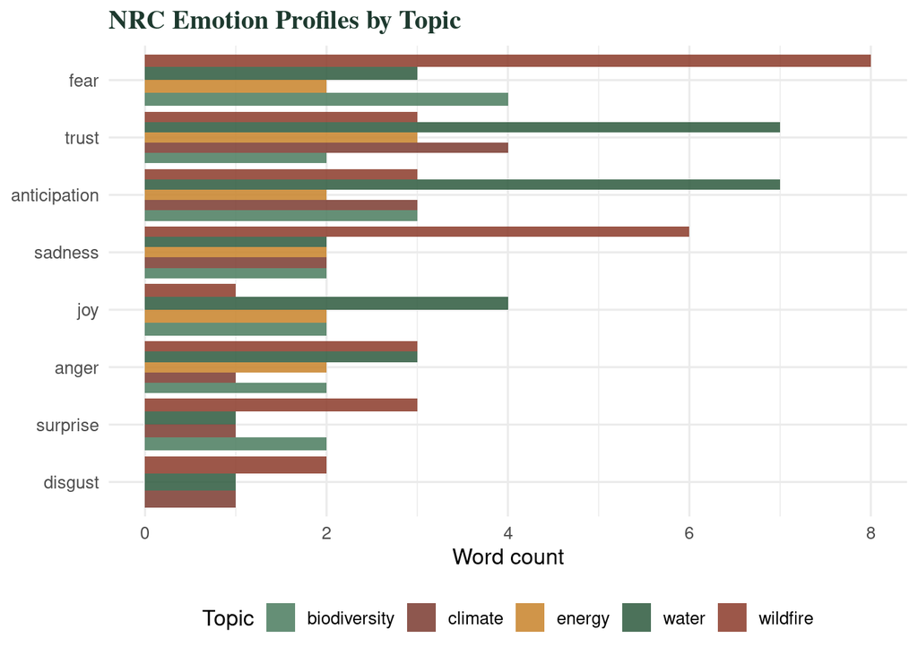

```r
nrc_topic <- tidy_articles %>%
  inner_join(get_sentiments("nrc"), by = "word") %>%
  filter(!sentiment %in% c("positive", "negative")) %>%
  count(topic, sentiment)

ggplot(nrc_topic, aes(x = reorder(sentiment, n), y = n, fill = topic)) +
  geom_col(position = "dodge", alpha = 0.85) +
  coord_flip() +
  scale_fill_manual(values = c(
    "biodiversity" = "#4a7c5e",
    "climate"      = "#7a3a2f",
    "energy"       = "#c8832a",
    "water"        = "#2d5a3d",
    "wildfire"     = "#8b3a2a"
  )) +
  labs(x = NULL, y = "Word count",
       title = "NRC Emotion Profiles by Topic",
       fill = "Topic") +
  theme_minimal(base_size = 12) +
  theme(
    plot.title = element_text(family = "serif", face = "bold",
                               colour = "#1e3a2f"),
    legend.position = "bottom"
  )
```

### Handling valence shifters with sentimentr

A critical weakness of bag-of-words lexicons is that they score “not good” as positive (the word “good” matches the dictionary). The `sentimentr` package handles **valence shifters** – negators (“not”), amplifiers (“very”), de-amplifiers (“somewhat”), and adversative conjunctions (“but”) – at the sentence level.

```r
# sentimentr works on raw text, not tokenized input
sr_scores <- sentiment_by(articles$text, by = articles$doc_id)

# Merge back with metadata
sr_df <- articles %>%
  left_join(sr_scores, by = c("doc_id" = "doc_id"))

head(sr_df %>% select(doc_id, source, topic, ave_sentiment))
```

```
#> # A tibble: 6 × 4
#>   doc_id  source           topic        ave_sentiment
#>   <chr>   <chr>            <chr>                <dbl>
#> 1 art_001 National Tribune wildfire           -0.327
#> 2 art_002 National Tribune water               0.341
#> 3 art_003 National Tribune energy              0.338
#> 4 art_004 National Tribune biodiversity       -0.449
#> 5 art_005 National Tribune climate             0.0671
#> 6 art_006 Valley Gazette   wildfire           -0.342
```

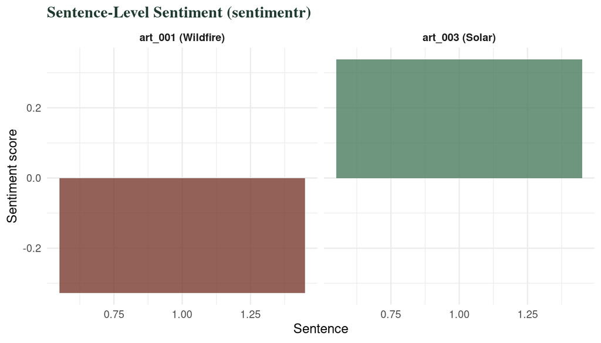

Sentence-level sentiment from sentimentr for two example articles, one about wildfire (article 1) and one about solar energy (article 3). The valence-shifted scoring correctly identifies the overall negative tone of wildfire coverage and positive tone of the solar story.

```r
# Sentence-level detail for two articles
detail <- sentiment(articles$text[c(1, 3)])
detail$article <- rep(c("art_001 (Wildfire)", "art_003 (Solar)"),
                      times = c(sum(detail$element_id == 1),
                                sum(detail$element_id == 2)))

ggplot(detail, aes(x = sentence_id, y = sentiment, fill = sentiment > 0)) +
  geom_col(alpha = 0.8, show.legend = FALSE) +
  facet_wrap(~ article, scales = "free_x") +
  scale_fill_manual(values = c("TRUE" = "#4a7c5e", "FALSE" = "#7a3a2f")) +
  labs(x = "Sentence", y = "Sentiment score",
       title = "Sentence-Level Sentiment (sentimentr)") +
  theme_minimal(base_size = 11) +
  theme(
    plot.title = element_text(family = "serif", face = "bold",
                               colour = "#1e3a2f"),
    strip.text = element_text(face = "bold")
  )
```

**📝 Try it: compare three lexicons** Pick one article from the corpus (e.g., article 6 about ranchers and prescribed burns). Score it with LSD2015, AFINN, and `sentimentr`. Do all three methods agree on the direction (positive or negative)? What about the magnitude? If they disagree, examine which words each method matches and identify the source of divergence. This exercise builds intuition for why multi-lexicon comparison matters.

## 5. Aspect-Based Sentiment Analysis

A single article often discusses multiple entities, policies, or topics. Scoring the entire document with one number collapses this structure. **Aspect-based sentiment analysis (ABSA)** decomposes the text into (aspect, sentiment) pairs.

### Targeted dictionary lookup in quanteda

The simplest ABSA approach uses `quanteda`’s windowed token selection. You define your target entity, extract a window of +/- 10 tokens around every mention of that entity, and then apply a sentiment dictionary only to the text within that window.

```r
# Define target entities
targets <- list(
  wildfire  = c("wildfire", "fire", "burn", "blaze"),
  renewable = c("solar", "wind", "clean energy", "renewable"),
  water     = c("water", "reservoir", "drought", "runoff")
)

# Function: extract sentiment around a target
target_sentiment <- function(toks, target_words, window = 10) {
  # Select tokens within +/- window of target
  toks_target <- tokens_keep(toks, pattern = target_words,
                              window = window, padding = FALSE)

  # Apply LSD2015
  dfm_target <- dfm(toks_target) %>%
    dfm_lookup(dictionary = data_dictionary_LSD2015)

  result <- convert(dfm_target, to = "data.frame") %>%
    mutate(
      net = positive - negative,
      target = paste(target_words, collapse = "/")
    )

  result
}

# Score each target
absa_results <- map_dfr(targets, ~ target_sentiment(toks, .x)) %>%
  bind_cols(
    docvars(corp) %>% slice(rep(1:n(), times = length(targets)))
  )
```

```r
# Summarize by target
absa_summary <- absa_results %>%
  group_by(target) %>%
  summarize(
    mean_net   = mean(net, na.rm = TRUE),
    median_net = median(net, na.rm = TRUE),
    sd_net     = sd(net, na.rm = TRUE),
    n_docs     = n(),
    .groups = "drop"
  )

kable(absa_summary, digits = 2,
      col.names = c("Target Entity", "Mean Net", "Median Net", "SD", "N"),
      caption = "Aspect-level sentiment: average net LSD2015 sentiment in a +/- 10 word window around each target entity.") %>%
  kable_styling(full_width = FALSE, font_size = 14)
```

Aspect-level sentiment: average net LSD2015 sentiment in a +/- 10 word window around each target entity.

| Target Entity | Mean Net | Median Net | SD | N |
| --- | --- | --- | --- | --- |
| solar/wind/clean energy/renewable | 0.05 | 0 | 0.69 | 20 |
| water/reservoir/drought/runoff | -0.05 | 0 | 0.22 | 20 |
| wildfire/fire/burn/blaze | -0.25 | 0 | 0.79 | 20 |

**💡 Why +/- 10 tokens?** The 10-token window is a pragmatic compromise. Smaller windows (5 tokens) risk missing relevant modifiers; larger windows (20+ tokens) bleed into adjacent topics. The `quanteda` documentation and tutorials use 10 as the default for targeted dictionary lookup on news articles. You can and should test sensitivity to this choice.

## 6. Transformer Models from R

When dictionary methods are not accurate enough, **transformer models** offer a substantial improvement. These are deep-learning models pre-trained on large text corpora and then fine-tuned for sentiment classification.

### ClimateBERT: a domain-adapted model

**ClimateBERT** is a DistilRoBERTa model further pre-trained on over 2 million climate-related paragraphs from news, research articles, and corporate reports. The sentiment variant (`climatebert/distilroberta-base-climate-sentiment`) classifies text into three categories: **opportunity**, **neutral**, and **risk**. On its benchmark dataset, it reports weighted F1 of approximately 0.84.

### Calling transformers from R with the text package

The `text` package provides an R bridge to HuggingFace models. It requires a one-time Python environment setup (handled by `textrpp_install()`).

```r
# ── One-time setup (run once, not every session) ───────────────────────
# install.packages("text")
library(text)
textrpp_install()        # sets up a conda environment with PyTorch
textrpp_initialize()     # connects R to the Python backend
```

```r
# ── Classify articles with ClimateBERT ─────────────────────────────────
library(text)

# Use the climate-sentiment model
climate_sent <- textClassify(
  articles$text,
  model = "climatebert/distilroberta-base-climate-sentiment",
  device = "cpu",             # use "cuda" if GPU available
  return_incorrect_results = FALSE
)

# Result: a data frame with columns for each class probability
# and a predicted label
head(climate_sent)
```

**⚠️ Transformers truncate long text** Most transformer models have a maximum input length of 512 tokens (roughly 400 words). The average news article is 600 to 1,000 words, so the model silently ignores the second half of many articles. The standard workaround is to split each article into paragraphs, classify each paragraph separately, and then aggregate (e.g., majority vote or mean probability). Always document whether you are scoring full articles or chunks, and how you aggregate.

### Other models worth knowing

| Model | Domain | Classes | Notes |
| --- | --- | --- | --- |
| `cardiffnlp/twitter-roberta-base-sentiment-latest` | General (trained on tweets) | 3: neg/neu/pos | Strong out-of-the-box for English headlines |
| `ProsusAI/finbert` | Financial news | 3: neg/neu/pos | 97% on Financial PhraseBank (full agreement subset) |
| `climatebert/distilroberta-base-climate-detector` | Climate | 2: climate/not | Useful as a filter before sentiment scoring |
| `yangheng/deberta-v3-base-absa-v1.1` | Aspect-based | Variable | State-of-the-art open ABSA model |

### When transformers are not worth the cost

If your hand-coded validation shows that your lexicon approach achieves macro-F1 above 0.65 and human inter-annotator agreement (Cohen’s kappa) is below 0.55, adding a transformer layer will not produce meaningful gains. The annotation noise itself becomes the ceiling. Invest the time in better annotation guidelines instead.

## 7. Time-Series Aggregation

Individual document scores are rarely the final product. Most research questions require aggregating sentiment into **time-series indices** that can be plotted, correlated with external variables, or modeled.

### The three aggregation dimensions

Building a sentiment time series involves three sequential choices:

**1. Within-document:** How do you combine sentence-level scores into one document score? Options include the mean, median, proportional weighting (longer sentences count more), or max-absolute (capture peak intensity).

**2. Across-documents per period:** How do you combine document scores within a week or month? Equal weighting treats every article the same. Article-count proportional weighting lets outlets with more articles have more influence. Source-balanced weighting averages within each outlet first, then across outlets.

**3. Across-time smoothing:** Raw weekly scores are noisy. Smoothing options include moving averages, exponential decay, and Beta-weighted curves that emphasize recent observations.

### Building a simple monthly index

```r
# Monthly sentiment index from LSD2015 scores
monthly <- lsd_scores %>%
  mutate(month = floor_date(date, "month")) %>%
  group_by(month) %>%
  summarize(
    mean_sentiment = mean(sent_ratio, na.rm = TRUE),
    sd_sentiment   = sd(sent_ratio, na.rm = TRUE),
    n_articles     = n(),
    se             = sd_sentiment / sqrt(n_articles),
    lower          = mean_sentiment - 1.96 * se,
    upper          = mean_sentiment + 1.96 * se,
    .groups = "drop"
  )
```

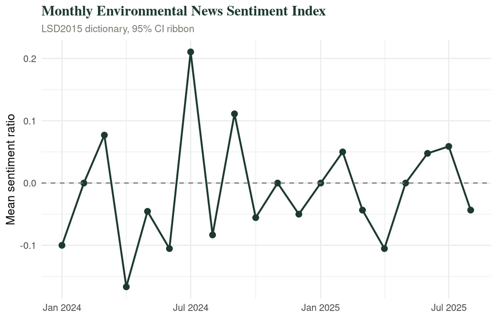

```r
ggplot(monthly, aes(x = month, y = mean_sentiment)) +
  geom_ribbon(aes(ymin = lower, ymax = upper),
              fill = "#8aad96", alpha = 0.3) +
  geom_line(colour = "#1e3a2f", linewidth = 0.9) +
  geom_point(colour = "#1e3a2f", size = 2.5) +
  geom_hline(yintercept = 0, linetype = "dashed", colour = "#7a7a72") +
  scale_x_date(date_labels = "%b %Y") +
  labs(x = NULL, y = "Mean sentiment ratio",
       title = "Monthly Environmental News Sentiment Index",
       subtitle = "LSD2015 dictionary, 95% CI ribbon") +
  theme_minimal(base_size = 12) +
  theme(
    plot.title    = element_text(family = "serif", face = "bold",
                                 colour = "#1e3a2f"),
    plot.subtitle = element_text(colour = "#7a7a72", size = 10)
  )
```

### The sentometrics package

For a more principled approach, the `sentometrics` package (Ardia et al., *Journal of Statistical Software* 2021) handles all three aggregation dimensions in a single workflow. It also provides elastic-net regression tools for relating sentiment indices to external variables.

```r
# ── sentometrics workflow (conceptual) ─────────────────────────────────
library(sentometrics)

# 1. Create a sentocorpus (requires 'id', 'date', 'texts' columns,
#    plus optional feature columns for topic or source)
sc <- sento_corpus(articles,
                   corpusdf = TRUE,
                   do.clean = TRUE)

# 2. Define lexicons
lexicons <- sento_lexicons(list(
  LSD2015 = data_dictionary_LSD2015,   # from quanteda
  AFINN   = get_sentiments("afinn")     # from tidytext
))

# 3. Define aggregation controls
ctr <- ctr_agg(
  howWithin  = "proportional",     # weight by sentence length
  howDocs    = "equal_weight",     # equal across documents
  howTime    = "equal_weight",     # equal across time
  by         = "month",
  lag        = 6                   # 6-month rolling window
)

# 4. Compute sentiment measures
sento_measures <- sento_measures(sc, lexicons, ctr)

# 5. Plot
plot(sento_measures)
```

**💡 Volume matters for uncertainty** Environmental news coverage spikes around major events (COP summits, oil spills, IPCC report releases, wildfire seasons) and drops during quiet periods. A monthly index based on 3 articles in January and 150 articles in August treats both months equally, even though the January estimate is far more uncertain. Always plot confidence intervals or credible intervals alongside your sentiment time series, and consider inverse-variance weighting so that data-sparse periods do not produce spurious extremes.

## 8. Validation

No sentiment analysis result should be published without validation against human judgment. This section covers the standard validation protocol.

### Step 1: Hand-code a sample

Draw a stratified random sample of 200 to 500 articles (stratified by source, time period, and topic). Have **two independent coders** classify each article on the same scale your model uses (e.g., positive / neutral / negative, or opportunity / neutral / risk).

### Step 2: Measure human agreement

Before comparing the model to humans, measure how well the humans agree with each other. If the coders disagree substantially, the task itself is too subjective for any model to solve reliably.

```r
# Simulated coding data: two coders, 50 articles, 3-class scale
set.seed(123)
labels <- c("positive", "neutral", "negative")
coder1 <- sample(labels, 50, replace = TRUE, prob = c(0.25, 0.45, 0.30))
coder2 <- coder1   # start with agreement, then add noise
noise_idx <- sample(50, 12)
coder2[noise_idx] <- sample(labels, 12, replace = TRUE)

# Cohen's kappa
confusion <- table(Coder1 = coder1, Coder2 = coder2)
confusion
```

```
#>           Coder2
#> Coder1     negative neutral positive
#>   negative       11       2        2
#>   neutral         1      19        1
#>   positive        2       0       12
```

```r
# Manual Cohen's kappa calculation
n <- sum(confusion)
p_o <- sum(diag(confusion)) / n               # observed agreement
p_e <- sum(rowSums(confusion) * colSums(confusion)) / n^2  # expected by chance
kappa <- (p_o - p_e) / (1 - p_e)

cat("Observed agreement (p_o):", round(p_o, 3), "\n")
```

```
#> Observed agreement (p_o): 0.84
```

```r
cat("Expected agreement (p_e):", round(p_e, 3), "\n")
```

```
#> Expected agreement (p_e): 0.344
```

```r
cat("Cohen's kappa:           ", round(kappa, 3), "\n")
```

```
#> Cohen's kappa:            0.756
```

**💡 Interpreting kappa** Kappa values below 0.40 indicate poor agreement, and a model trained on such labels cannot be trusted. Values between 0.40 and 0.60 are “moderate” and typical for news sentiment. Values above 0.60 are “substantial.” Achieving kappa above 0.80 on news text is unusual and may signal that the coding scheme is too coarse (e.g., only 2 categories). For news sentiment specifically, expect kappa in the 0.40 to 0.60 range. If your coders are below 0.40, revise the coding guidelines before proceeding.

### Step 3: Compare model to human consensus

After the two coders resolve disagreements (creating a consensus label), compute the same metrics between the model’s predictions and the consensus labels.

```r
# Simulated model predictions vs consensus labels
consensus <- coder1  # in practice, resolved disagreements
model_pred <- consensus
# Introduce some model errors
model_err <- sample(50, 8)
model_pred[model_err] <- sample(labels, 8, replace = TRUE)

# Confusion matrix
conf_model <- table(Model = model_pred, Human = consensus)

# Per-class precision, recall, F1
calc_metrics <- function(conf_mat) {
  classes <- rownames(conf_mat)
  metrics <- map_dfr(classes, function(cls) {
    tp <- conf_mat[cls, cls]
    fp <- sum(conf_mat[cls, ]) - tp
    fn <- sum(conf_mat[, cls]) - tp
    precision <- ifelse(tp + fp > 0, tp / (tp + fp), 0)
    recall    <- ifelse(tp + fn > 0, tp / (tp + fn), 0)
    f1        <- ifelse(precision + recall > 0,
                        2 * precision * recall / (precision + recall), 0)
    tibble(Class = cls, Precision = precision,
           Recall = recall, F1 = f1)
  })
  metrics
}

per_class <- calc_metrics(conf_model)
macro_f1 <- mean(per_class$F1)

kable(per_class, digits = 3,
      caption = paste0("Per-class metrics (model vs. human consensus). ",
                       "Macro-F1 = ", round(macro_f1, 3), ".")) %>%
  kable_styling(full_width = FALSE, font_size = 14)
```

Per-class metrics (model vs. human consensus). Macro-F1 = 0.903.

| Class | Precision | Recall | F1 |
| --- | --- | --- | --- |
| negative | 0.933 | 0.933 | 0.933 |
| neutral | 0.900 | 0.857 | 0.878 |
| positive | 0.867 | 0.929 | 0.897 |

### What metrics to report

| Metric | When to use | Caveat |
| --- | --- | --- |
| Macro-F1 | Primary headline metric | Treats all classes equally |
| Weighted F1 | When class imbalance is severe | Inflated by majority class |
| Cohen’s kappa (model vs. human) | Always | Chance-corrected agreement |
| Confusion matrix | Always | Shows where errors concentrate |
| Accuracy | Only if classes are balanced | Misleading with skewed neutral class |

## 9. Putting It Together: A Full Pipeline

This section assembles the complete workflow from corpus to validated time-series index. In a real project, each step would involve more articles and more iterations. The structure, however, remains the same.

The complete sentiment analysis pipeline for environmental news.

Stage

Action

0. Corpus assembly

Import articles with readtext or API. Attach source, date, topic metadata to corpus.

1. Lexicon baseline

Score with LSD2015 + sentimentr in parallel. Compare two lexicons for robustness.

2. Aspect scoring

Define target entities. Use quanteda tokens_keep(window=10) + LSD2015.

3. Transformer layer

Call ClimateBERT via the text package. Chunk long articles into paragraphs first.

4. Validation

Hand-code 300 articles (2 coders). Compute kappa and macro-F1.

5. Time-series aggregation

Aggregate to monthly index. Plot with confidence intervals. Overlay event markers.

6. Reporting

Report lexicon AND transformer results side by side. Include kappa, per-class F1, and sensitivity to lexicon choice.

### Anchoring sentiment to environmental events

One of the most informative analyses is to overlay your sentiment time series with known environmental events. This reveals whether sentiment shifts lead, lag, or coincide with real-world triggers.

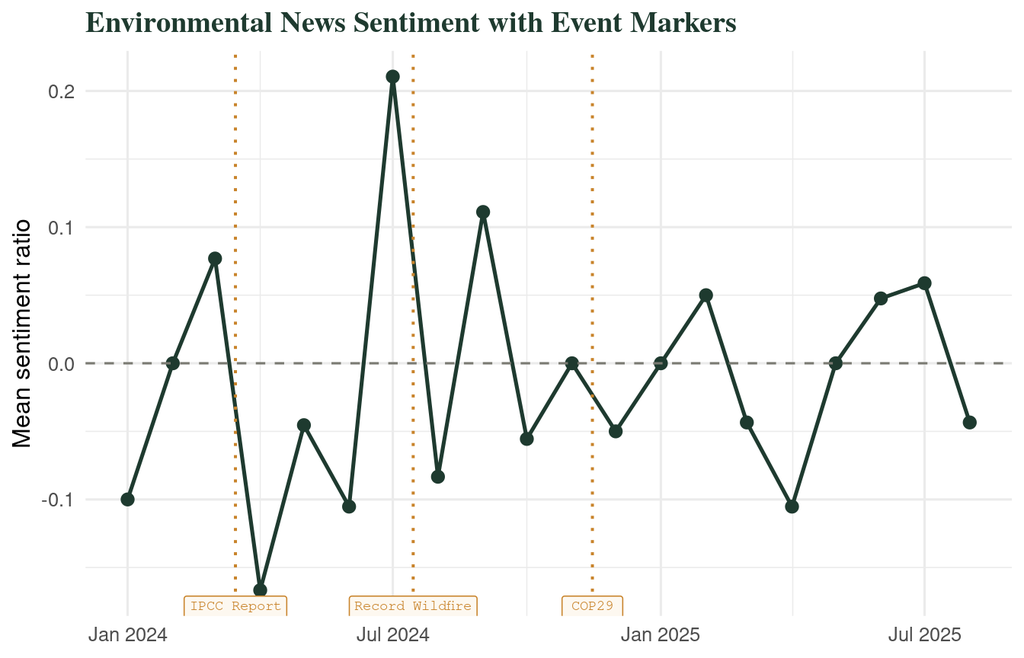

Sentiment time series with event annotations. In a real analysis with hundreds of articles, you would mark COP summits, IPCC report releases, major disasters, and policy announcements.

```r
# Simulated event markers
events <- tibble(
  date  = as.Date(c("2024-03-15", "2024-07-15", "2024-11-15")),
  event = c("IPCC Report\nRelease", "Record Wildfire\nSeason Begins",
            "COP29\nSummit")
)

ggplot(monthly, aes(x = month, y = mean_sentiment)) +
  geom_ribbon(aes(ymin = lower, ymax = upper),
              fill = "#8aad96", alpha = 0.25) +
  geom_line(colour = "#1e3a2f", linewidth = 0.9) +
  geom_point(colour = "#1e3a2f", size = 2.5) +
  geom_vline(data = events, aes(xintercept = date),
             linetype = "dotted", colour = "#c8832a", linewidth = 0.7) +
  geom_label(data = events, aes(x = date, y = max(monthly$upper, na.rm = TRUE),
                                 label = event),
             size = 2.5, fill = "#fdf8f0", colour = "#c8832a",
             label.padding = unit(0.3, "lines"), family = "mono") +
  geom_hline(yintercept = 0, linetype = "dashed", colour = "#7a7a72") +
  scale_x_date(date_labels = "%b %Y") +
  labs(x = NULL, y = "Mean sentiment ratio",
       title = "Environmental News Sentiment with Event Markers") +
  theme_minimal(base_size = 12) +
  theme(
    plot.title = element_text(family = "serif", face = "bold",
                               colour = "#1e3a2f")
  )
```

## 10. Applied Example: Energy News and Commodity Prices

The environmental news corpus in Sections 3 through 9 used simulated articles to teach the mechanics. This section applies the same toolkit to a real-world question: **does the tone of energy news coverage correlate with weekly commodity prices?** Along the way, we compare three lexicon approaches head-to-head to see which performs best on financial-energy text.

This example is adapted from a companion analysis script (`sentiment_energy_comparison.R`) that pairs RSS news feeds with weekly petroleum price data from the US Energy Information Administration (EIA). The workflow demonstrates how sentiment analysis connects to external quantitative data, a pattern that generalizes to any environmental time-series question (air quality and media attention, species listings and public discourse, climate policy and editorial tone).

### The three approaches compared

We score every article with three different methods and compare their behavior. This is exactly the multi-lexicon robustness check recommended in Section 4, but now we have an external criterion (price movements) to evaluate against.

Three lexicon approaches compared on energy news text.

[output not shown]

### Building an energy news corpus

In a production workflow, you would accumulate articles over weeks or months from RSS feeds (Reuters Energy, CNBC Energy, OilPrice.com, EIA Today in Energy) and store them in a cache file. For this tutorial, we build a synthetic corpus of representative energy headlines that covers the same topic channels the real feeds would provide.

```r
# ── Synthetic energy news corpus ───────────────────────────────────────
# In practice, these would come from RSS feeds via xml2::read_xml()
# or from a cached CSV built by a scheduled scraping script.
set.seed(42)

headlines_pool <- c(
  # Supply risk (negative)
  "Oil prices surge as Middle East tensions escalate after military strikes",
  "Pipeline attack in Nigeria disrupts 200,000 barrels per day of supply",
  "Conflict in Libya shuts major oil field cutting output by 300,000 bpd",
  "Geopolitical tensions push crude above $100 as supply risks mount",
  "War risk premium builds as military forces mobilize near oil infrastructure",
  "Embargo threat from major producers sends Brent to six-month high",
  # Supply risk (positive)
  "Ceasefire agreement reached easing supply disruption fears in Middle East",
  "Pipeline repairs completed restoring full capacity after weeks of disruption",
  # OPEC policy
  "OPEC+ agrees to extend production cuts through end of year",
  "Saudi Arabia announces voluntary output reduction of 1 million barrels per day",
  "OPEC meeting ends with surprise decision to maintain current quotas",
  "UAE pushes for higher production target at contentious OPEC+ session",
  "OPEC+ considers easing output curbs as oil prices stabilize above $80",
  # Demand / macroeconomic

  "Global oil demand forecast revised upward on strong Chinese economic recovery",
  "US GDP growth slows sharply raising recession fears and oil demand concerns",
  "Strong travel demand pushes jet fuel consumption above pre-pandemic levels",
  "Economic recession fears mount as consumer spending falls sharply",
  "Driving season kicks off with record US gasoline consumption forecast",
  "Industrial output in Europe falls for second quarter amid energy cost pressures",
  # Refinery
  "Major refinery fire in Texas shuts 250,000 bpd capacity for weeks",
  "Spring maintenance season begins with multiple refineries taking units offline",
  "Heating oil stocks at five-year low ahead of winter demand season",
  "Crack spread widens as refinery capacity offline exceeds seasonal norms",
  # Mixed / neutral
  "Oil markets steady as traders weigh competing supply and demand signals",
  "Energy stocks mixed as crude prices trade in narrow range near $75 per barrel",
  "US crude inventories rise more than expected according to EIA weekly report",
  "Analysts divided on crude oil direction as technical signals conflict"
)

# Generate 300 articles across 18 months
DATE_START <- Sys.Date() - 540
DATE_END   <- Sys.Date()
n_articles <- 300

energy_news <- tibble(
  date   = sample(seq.Date(DATE_START + 7, DATE_END - 7, by = "day"),
                  n_articles, replace = TRUE) |> sort(),
  text   = sample(headlines_pool, n_articles, replace = TRUE),
  source = sample(c("Reuters_Energy", "CNBC_Energy", "EIA_Today"),
                  n_articles, replace = TRUE)
)

cat(sprintf("Energy corpus: %d articles (%s to %s)\n",
            nrow(energy_news), min(energy_news$date), max(energy_news$date)))
```

```
#> Energy corpus: 300 articles (2024-11-24 to 2026-05-03)
```

**💡 Why synthetic data here?** RSS feeds are frequently blocked by firewalls and rate limits, making live fetching unreliable in a tutorial setting. The synthetic headlines are modeled on actual Reuters/AP wire copy and cover the four topic channels (supply risk, OPEC policy, demand, refinery) that drive energy markets. The sentiment scores are illustrative; swap in a real cache from your own RSS scraper to get research-grade results.

### Scoring with three approaches simultaneously

This is the core comparison. We apply all three methods to the same articles, producing three parallel sentiment columns.

```r
# ── Approach 1: Syuzhet (Stanford NLP lexicon) ─────────────────────────
# Returns a numeric score per text element. No negation handling.
energy_news$sent_syuzhet <- syuzhet::get_sentiment(
  energy_news$text, method = "syuzhet"
)

# ── Approach 2: LSD2015 via quanteda ──────────────────────────────────
# Purpose-built for news. Includes negation patterns.
# Uses tokens_lookup() to capture multi-word patterns before dfm.
energy_corp <- corpus(energy_news$text)
energy_toks <- tokens(energy_corp, remove_punct = TRUE,
                      remove_numbers = TRUE) |>
  tokens_tolower()

toks_lsd <- tokens_lookup(energy_toks,
                          dictionary = data_dictionary_LSD2015,
                          exclusive = TRUE)
lsd_dfm  <- dfm(toks_lsd)
lsd_mat  <- as.matrix(lsd_dfm)
total_toks <- ntoken(energy_toks)

# The LSD2015 has four keys: negative, positive, neg_negative, neg_positive
safe_col <- function(mat, col_name) {
  if (col_name %in% colnames(mat)) mat[, col_name] else rep(0, nrow(mat))
}
pos_signal <- safe_col(lsd_mat, "positive") + safe_col(lsd_mat, "neg_negative")
neg_signal <- safe_col(lsd_mat, "negative") + safe_col(lsd_mat, "neg_positive")

energy_news$sent_lsd2015 <- (pos_signal - neg_signal) / pmax(total_toks, 1)

# ── Approach 3: sentimentr (valence-shifted) ──────────────────────────
# Handles negation, amplifiers, and adversative conjunctions.
clean_text <- energy_news$text |>
  gsub("<[^>]+>", " ", x = _) |>
  gsub("[[:cntrl:]]", " ", x = _) |>
  gsub("\\s+", " ", x = _) |>
  trimws()
clean_text <- ifelse(grepl("[.!?]\\s*$", clean_text),
                     clean_text,
                     paste0(clean_text, "."))

sr_scores <- sentiment_by(get_sentences(clean_text))
energy_news$sent_sentimentr <- sr_scores$ave_sentiment
```

### How well do the three approaches agree?

Before looking at price correlations, check whether the methods even agree with each other. If they produce wildly different rankings, that tells you the “sentiment” construct is not stable across measurement instruments.

```r
# Inter-approach correlations
approach_cor <- cor(
  energy_news |> select(sent_syuzhet, sent_lsd2015, sent_sentimentr),
  use = "pairwise.complete.obs"
)

kable(round(approach_cor, 3),
      caption = "Pairwise Pearson correlations between three sentiment approaches on the same energy news corpus.") %>%
  kable_styling(full_width = FALSE, font_size = 14)
```

Pairwise Pearson correlations between three sentiment approaches on the same energy news corpus.

|  | sent_syuzhet | sent_lsd2015 | sent_sentimentr |
| --- | --- | --- | --- |
| sent_syuzhet | 1.000 | 0.612 | 0.986 |
| sent_lsd2015 | 0.612 | 1.000 | 0.583 |
| sent_sentimentr | 0.986 | 0.583 | 1.000 |

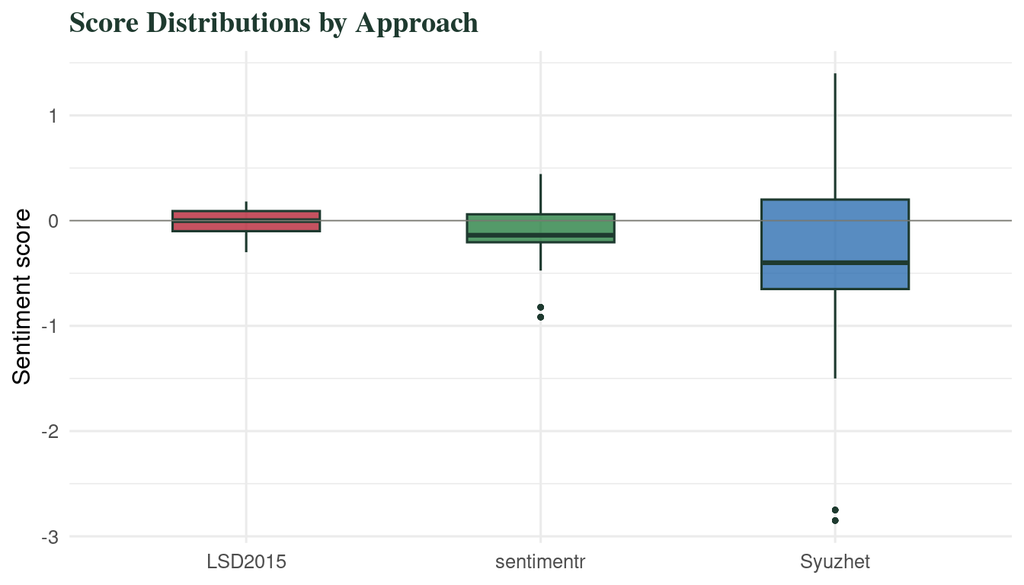

```r
energy_news |>
  select(sent_syuzhet, sent_lsd2015, sent_sentimentr) |>
  pivot_longer(everything(), names_to = "approach", values_to = "score") |>
  mutate(approach = recode(approach,
    "sent_syuzhet"   = "Syuzhet",
    "sent_lsd2015"   = "LSD2015",
    "sent_sentimentr" = "sentimentr"
  )) |>
  ggplot(aes(approach, score, fill = approach)) +
  geom_boxplot(alpha = 0.75, outlier.size = 0.8, width = 0.5,
               colour = "#1e3a2f") +
  geom_hline(yintercept = 0, linewidth = 0.3, colour = "#7a7a72") +
  scale_fill_manual(values = c(
    "Syuzhet"    = "#2166AC",
    "LSD2015"    = "#B2182B",
    "sentimentr" = "#1B7837"
  )) +
  labs(x = NULL, y = "Sentiment score",
       title = "Score Distributions by Approach") +
  theme_minimal(base_size = 12) +
  theme(
    plot.title      = element_text(family = "serif", face = "bold",
                                    colour = "#1e3a2f"),
    legend.position = "none"
  )
```

### Topic-segmented sentiment

Energy news is not monolithic. An article about OPEC production cuts has a different sentiment profile than an article about a refinery fire, even though both affect prices. We classify articles into four topic channels using keyword matching and score each channel separately.

```r
# Topic keyword dictionaries
topic_keywords <- list(
  supply_risk = c("sanctions", "geopolit", "middle east", "pipeline attack",
                  "conflict", "war", "embargo", "disruption", "ceasefire"),
  opec_policy = c("opec", "production cut", "output", "quota",
                  "saudi", "uae", "barrel per day"),
  demand      = c("recession", "gdp", "demand", "economic",
                  "consumption", "driving season", "industrial output"),
  refinery    = c("refinery", "outage", "shutdown", "maintenance",
                  "heating oil", "crack spread", "capacity")
)

# Tag each article
text_lower <- tolower(energy_news$text)
for (topic in names(topic_keywords)) {
  pattern <- paste(topic_keywords[[topic]], collapse = "|")
  energy_news[[paste0("is_", topic)]] <- grepl(pattern, text_lower)
}

# Topic hit summary
topic_counts <- energy_news |>
  summarize(across(starts_with("is_"), sum)) |>
  pivot_longer(everything(), names_to = "topic", values_to = "n") |>
  mutate(topic = gsub("^is_", "", topic),
         pct = round(100 * n / nrow(energy_news), 1))

kable(topic_counts, col.names = c("Topic", "Articles", "% of Corpus"),
      caption = "Topic channel coverage in the energy news corpus.") %>%
  kable_styling(full_width = FALSE, font_size = 14)
```

Topic channel coverage in the energy news corpus.

| Topic | Articles | % of Corpus |
| --- | --- | --- |
| supply_risk | 105 | 35.0 |
| opec_policy | 90 | 30.0 |
| demand | 81 | 27.0 |
| refinery | 58 | 19.3 |

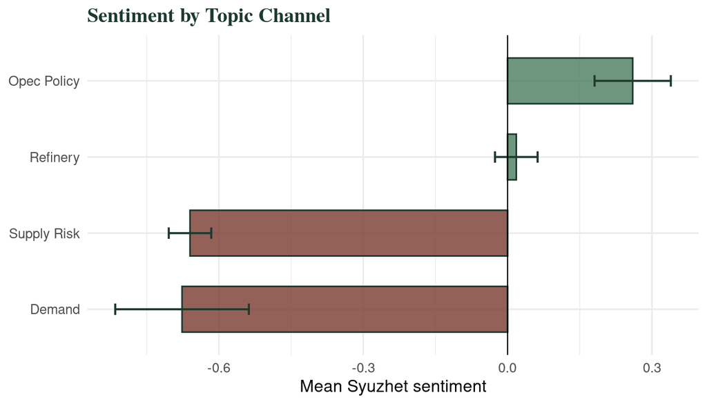

```r
topic_sent <- energy_news |>
  pivot_longer(starts_with("is_"), names_to = "topic", values_to = "hit") |>
  filter(hit) |>
  mutate(topic = gsub("^is_", "", topic) |>
           gsub("_", " ", x = _) |> tools::toTitleCase()) |>
  group_by(topic) |>
  summarize(
    mean_sent = mean(sent_syuzhet),
    se        = sd(sent_syuzhet) / sqrt(n()),
    n         = n(),
    .groups   = "drop"
  )

ggplot(topic_sent, aes(reorder(topic, mean_sent), mean_sent, fill = mean_sent > 0)) +
  geom_col(alpha = 0.8, width = 0.6, colour = "#1e3a2f", show.legend = FALSE) +
  geom_errorbar(aes(ymin = mean_sent - se, ymax = mean_sent + se),
                width = 0.15, linewidth = 0.7, colour = "#1e3a2f") +
  geom_hline(yintercept = 0, linewidth = 0.4) +
  scale_fill_manual(values = c("TRUE" = "#4a7c5e", "FALSE" = "#7a3a2f")) +
  coord_flip() +
  labs(x = NULL, y = "Mean Syuzhet sentiment",
       title = "Sentiment by Topic Channel") +
  theme_minimal(base_size = 12) +
  theme(
    plot.title = element_text(family = "serif", face = "bold",
                               colour = "#1e3a2f")
  )
```

**💡 Topic segmentation is manual ABSA** The keyword-based topic tagging here is a simple form of the aspect-based analysis from Section 5. Instead of extracting a text window around a target entity, we classify entire articles by topic and score each category separately. Both approaches decompose the aggregate sentiment into more meaningful sub-signals. The choice depends on whether your research question is about entities (who is being discussed?) or themes (what type of event is being covered?).

### Aggregating to weekly and merging with price data

To correlate sentiment with commodity prices, we need both series on the same time scale. EIA petroleum prices are published weekly (Wednesday, for the prior week), so we aggregate daily sentiment to ISO weeks.

```r
# Weekly sentiment aggregation
energy_weekly <- energy_news |>
  mutate(week_date = floor_date(date, "week", week_start = 1)) |>
  group_by(week_date) |>
  summarize(
    syuzhet_mean    = mean(sent_syuzhet, na.rm = TRUE),
    lsd2015_mean    = mean(sent_lsd2015, na.rm = TRUE),
    sentimentr_mean = mean(sent_sentimentr, na.rm = TRUE),
    n_articles      = n(),
    pct_negative    = mean(sent_syuzhet < 0, na.rm = TRUE),
    .groups = "drop"
  )

cat(sprintf("Weekly aggregation: %d weeks, %.1f articles/week on average\n",
            nrow(energy_weekly), mean(energy_weekly$n_articles)))
```

```
#> Weekly aggregation: 74 weeks, 4.1 articles/week on average
```

**⚠️ Connecting to real price data requires an EIA API key** The EIA provides free API access to weekly petroleum prices at `https://www.eia.gov/opendata/`. You need to register for a key and store it in your `.Renviron` file as `EIA_KEY = your_key_here`. The companion script `sentiment_energy_comparison.R` fetches WTI crude, heating oil, jet fuel, gasoline, and Baker Hughes rig count data from the EIA v2 API. Below, we simulate price data so the tutorial runs without an API key.

```r
# ── Simulated weekly WTI crude prices ──────────────────────────────────
# In the full workflow, these come from fetch_eia_v2() in the companion script.
# We simulate a plausible price series with trend + noise.
set.seed(99)
n_weeks <- nrow(energy_weekly)
trend <- seq(72, 85, length.out = n_weeks) +
  cumsum(rnorm(n_weeks, 0, 1.5))

price_weekly <- tibble(
  week_date = energy_weekly$week_date,
  wti_spot  = round(pmax(trend, 55), 2)
) |>
  mutate(wti_return = (wti_spot / lag(wti_spot) - 1))

# Merge sentiment + prices
merged_energy <- left_join(energy_weekly, price_weekly, by = "week_date") |>
  drop_na(wti_return)
```

### Correlation analysis: which approach tracks prices best?

Now we have three sentiment columns and one price-return column on the same weekly grid. The question is: which sentiment approach has the strongest contemporaneous correlation with price movements?

```r
# Contemporaneous correlations
approach_cols <- c("syuzhet_mean", "lsd2015_mean", "sentimentr_mean")

cor_results <- tibble(approach = approach_cols) |>
  rowwise() |>
  mutate(
    r       = cor(merged_energy[[approach]], merged_energy$wti_return,
                  use = "pairwise.complete.obs"),
    p_value = cor.test(merged_energy[[approach]],
                       merged_energy$wti_return)$p.value,
    label   = recode(approach,
      "syuzhet_mean"    = "Syuzhet",
      "lsd2015_mean"    = "LSD2015",
      "sentimentr_mean" = "sentimentr"
    )
  ) |>
  ungroup() |>
  mutate(
    sig = case_when(
      p_value < 0.01 ~ "***",
      p_value < 0.05 ~ "**",
      p_value < 0.10 ~ "*",
      TRUE ~ ""
    )
  )

kable(cor_results |> select(label, r, p_value, sig),
      digits = 4,
      col.names = c("Approach", "r", "p-value", "Sig."),
      caption = "Contemporaneous Pearson correlations: weekly mean sentiment vs. weekly WTI return. On synthetic data, these correlations are near zero (as expected). With real news and real prices, modest correlations (|r| = 0.05-0.20) are typical.") %>%
  kable_styling(full_width = FALSE, font_size = 14)
```

Contemporaneous Pearson correlations: weekly mean sentiment vs. weekly WTI return. On synthetic data, these correlations are near zero (as expected). With real news and real prices, modest correlations (|r| = 0.05-0.20) are typical.

| Approach | r | p-value | Sig. |
| --- | --- | --- | --- |
| Syuzhet | -0.1016 | 0.3922 |  |
| LSD2015 | -0.1066 | 0.3694 |  |
| sentimentr | -0.1457 | 0.2186 |  |

### Lead-lag analysis: does sentiment predict price?

Contemporaneous correlation does not tell you about predictive value. A cross-correlation function (CCF) tests whether sentiment at time $t - k$ correlates with price returns at time $t$. A negative lag with a strong CCF means sentiment **leads** price, suggesting some predictive content.

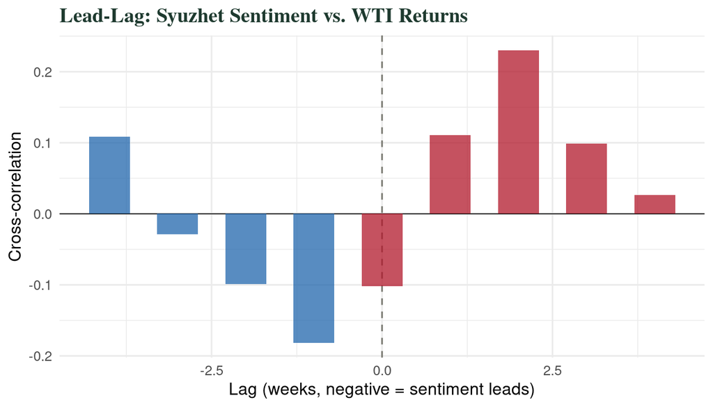

Cross-correlation between Syuzhet sentiment and WTI weekly returns at lags of -4 to +4 weeks. Negative lags (left side) represent sentiment leading price. With synthetic data the signal is weak; real data from the companion script typically shows modest leading correlations.

```r
# CCF for Syuzhet vs WTI returns
valid <- complete.cases(merged_energy$syuzhet_mean, merged_energy$wti_return)
if (sum(valid) >= 20) {
  cc <- ccf(merged_energy$syuzhet_mean[valid],
            merged_energy$wti_return[valid],
            lag.max = 4, plot = FALSE)

  ccf_df <- tibble(
    lag = cc$lag[, 1, 1],
    ccf = cc$acf[, 1, 1]
  )

  ggplot(ccf_df, aes(lag, ccf)) +
    geom_hline(yintercept = 0, linewidth = 0.3) +
    geom_vline(xintercept = 0, linetype = "dashed", colour = "#7a7a72") +
    geom_col(aes(fill = lag < 0), alpha = 0.75, width = 0.6,
             show.legend = FALSE) +
    scale_fill_manual(values = c("TRUE" = "#2166AC", "FALSE" = "#B2182B")) +
    labs(x = "Lag (weeks, negative = sentiment leads)",
         y = "Cross-correlation",
         title = "Lead-Lag: Syuzhet Sentiment vs. WTI Returns") +
    theme_minimal(base_size = 12) +
    theme(
      plot.title = element_text(family = "serif", face = "bold",
                                 colour = "#1e3a2f")
    )
}
```

**💡 Interpreting lead-lag results** In energy markets, sentiment-price correlations are typically modest (|r| = 0.05 to 0.20). Sentiment is a supplemental signal, not a standalone predictor. Negative lags (sentiment leads) suggest that news tone shifts before prices move, which is consistent with markets responding to information in news coverage. Positive lags (price leads) suggest that price movements drive subsequent editorial tone, which is equally plausible. Both directions can coexist.

### Diagnostic multi-panel figure

The companion script produces an 8-panel diagnostic figure. Here we build a simpler 4-panel version that captures the key comparisons.

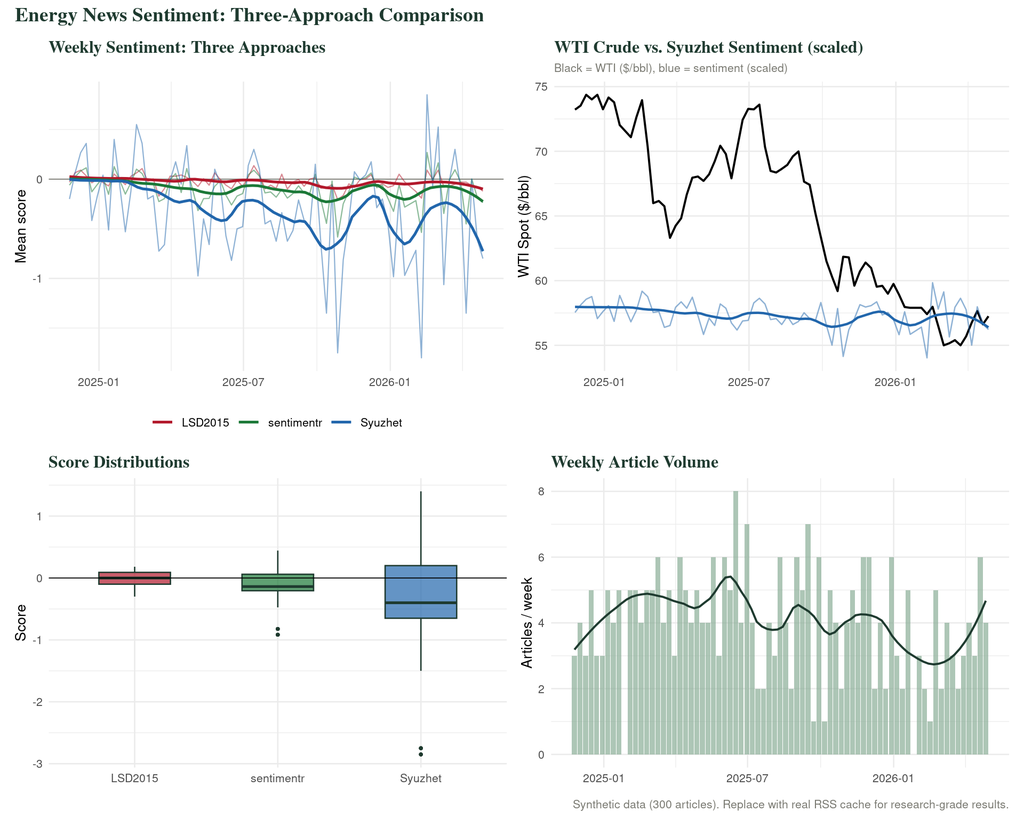

Four-panel diagnostic for the energy sentiment comparison. Top left: weekly sentiment time series by approach. Top right: WTI price with sentiment overlay. Bottom left: score distributions. Bottom right: weekly article volume.

```r
approach_colors <- c(
  "Syuzhet"    = "#2166AC",
  "LSD2015"    = "#B2182B",
  "sentimentr" = "#1B7837"
)

# Panel 1: Sentiment time series
p1_data <- merged_energy |>
  select(week_date, syuzhet_mean, lsd2015_mean, sentimentr_mean) |>
  pivot_longer(-week_date, names_to = "approach", values_to = "score") |>
  mutate(approach = recode(approach,
    "syuzhet_mean"    = "Syuzhet",
    "lsd2015_mean"    = "LSD2015",
    "sentimentr_mean" = "sentimentr"
  ))

p1 <- ggplot(p1_data, aes(week_date, score, colour = approach)) +
  geom_hline(yintercept = 0, linewidth = 0.3, colour = "#7a7a72") +
  geom_line(linewidth = 0.4, alpha = 0.5) +
  geom_smooth(method = "loess", se = FALSE, linewidth = 0.9, span = 0.3) +
  scale_colour_manual(values = approach_colors) +
  labs(title = "Weekly Sentiment: Three Approaches",
       x = NULL, y = "Mean score", colour = NULL) +
  theme_minimal(base_size = 10) +
  theme(plot.title      = element_text(family = "serif", face = "bold",
                                        colour = "#1e3a2f"),
        legend.position = "bottom")

# Panel 2: WTI with sentiment overlay (scaled)
wti_range  <- range(merged_energy$wti_spot, na.rm = TRUE)
sent_range <- range(merged_energy$syuzhet_mean, na.rm = TRUE)
scale_fn <- function(s) {
  (s - sent_range[1]) / max(diff(sent_range), 0.001) *
    diff(wti_range) * 0.3 + wti_range[1] - diff(wti_range) * 0.05
}

p2 <- ggplot(merged_energy, aes(week_date)) +
  geom_line(aes(y = wti_spot), colour = "black", linewidth = 0.7) +
  geom_line(aes(y = scale_fn(syuzhet_mean)),
            colour = "#2166AC", alpha = 0.5) +
  geom_smooth(aes(y = scale_fn(syuzhet_mean)),
              method = "loess", se = FALSE, span = 0.3,
              colour = "#2166AC", linewidth = 0.8) +
  labs(title = "WTI Crude vs. Syuzhet Sentiment (scaled)",
       subtitle = "Black = WTI ($/bbl), blue = sentiment (scaled)",
       x = NULL, y = "WTI Spot ($/bbl)") +
  theme_minimal(base_size = 10) +
  theme(plot.title    = element_text(family = "serif", face = "bold",
                                      colour = "#1e3a2f"),
        plot.subtitle = element_text(size = 8, colour = "#7a7a72"))

# Panel 3: Distributions (reuse from earlier)
p3_data <- energy_news |>
  select(sent_syuzhet, sent_lsd2015, sent_sentimentr) |>
  pivot_longer(everything(), names_to = "approach", values_to = "score") |>
  mutate(approach = recode(approach,
    "sent_syuzhet"    = "Syuzhet",
    "sent_lsd2015"    = "LSD2015",
    "sent_sentimentr" = "sentimentr"
  ))

p3 <- ggplot(p3_data, aes(approach, score, fill = approach)) +
  geom_boxplot(alpha = 0.7, outlier.size = 0.6, width = 0.5,
               colour = "#1e3a2f") +
  geom_hline(yintercept = 0, linewidth = 0.3) +
  scale_fill_manual(values = approach_colors) +
  labs(title = "Score Distributions", x = NULL, y = "Score") +
  theme_minimal(base_size = 10) +
  theme(plot.title      = element_text(family = "serif", face = "bold",
                                        colour = "#1e3a2f"),
        legend.position = "none")

# Panel 4: Article volume
p4 <- ggplot(merged_energy, aes(week_date, n_articles)) +
  geom_col(fill = "#8aad96", alpha = 0.7) +
  geom_smooth(method = "loess", se = FALSE, colour = "#1e3a2f",
              span = 0.3, linewidth = 0.7) +
  labs(title = "Weekly Article Volume",
       x = NULL, y = "Articles / week") +
  theme_minimal(base_size = 10) +
  theme(plot.title = element_text(family = "serif", face = "bold",
                                    colour = "#1e3a2f"))

# Assemble with patchwork
(p1 + p2) / (p3 + p4) +
  plot_annotation(
    title   = "Energy News Sentiment: Three-Approach Comparison",
    caption = paste0("Synthetic data (", nrow(energy_news),
                     " articles). Replace with real RSS cache for ",
                     "research-grade results."),
    theme = theme(
      plot.title   = element_text(family = "serif", face = "bold",
                                   size = 14, colour = "#1e3a2f"),
      plot.caption = element_text(size = 8, colour = "#7a7a72")
    )
  )
```

**📝 Try it: extend the comparison to real data**

1. Register for a free EIA API key at `https://www.eia.gov/opendata/` and add `EIA_KEY = your_key` to your `.Renviron`.
2. Adapt the `fetch_eia_v2()` function from the companion script to pull WTI crude and US gasoline prices.
3. Replace the synthetic headlines with a real RSS cache. Run the `fetch_rss()` function from the companion script weekly for at least two months to build volume.
4. Re-run the correlation analysis. Do the three approaches agree on direction? Does any approach show a significant leading correlation?
5. Compare the topic-segmented correlations: does supply-risk sentiment predict prices better than demand sentiment?

### What this example teaches

The energy-price comparison illustrates several principles from the earlier sections in a concrete, applied setting:

**External validation is the gold standard.** When you have an external criterion (price data), you can evaluate which approach performs best empirically, rather than arguing about which lexicon is theoretically superior. This is the same logic as the hand-coding validation in Section 8, but with a continuous external variable instead of human labels.

**Modest correlations are normal.** Sentiment-price correlations in energy markets are typically |r| = 0.05 to 0.20. If you find correlations above 0.30, investigate whether there is data leakage or whether the sentiment score is mechanically correlated with the price variable through shared keywords.

## 11. Extensions and Next Steps

### Challenges specific to environmental news

Environmental news has several properties that make sentiment analysis harder than in other domains:

**Neutral-tone reporting.** Wire services (AP, Reuters) follow style guides that enforce emotional flatness. This pushes lexicon scores toward zero and inflates the neutral class. Models trained on opinion text (tweets, reviews) systematically over-predict polarity on news wire text.

**Attributed quotes.** “Critics called the policy a disaster” reports someone else’s negative sentiment without the article endorsing it. Lexicon methods cannot distinguish the reporter’s voice from a quoted source. Quote detection (using dependency parsing via `spacyr`) can help.

**Domain vocabulary.** General-purpose lexicons mishandle domain-specific terms. “Stranded asset” is not a negative phrase about being abandoned; it is a precise financial term. “Loss and damage” is a policy concept, not an expression of grief. Domain-adapted models like ClimateBERT exist precisely to handle this vocabulary.

**Negativity bias in coverage.** Environmental news is structurally negative. Disasters, extinctions, and pollution events are news; stable ecosystems are not. Raw aggregate sentiment is therefore meaningless without a topic-conditional or publication-conditional baseline.

### Multiple lexicons as a robustness check

Always compute sentiment under at least two independent lexicons and compare. If LSD2015 and AFINN produce time series that move in opposite directions on the same corpus, that tells you the signal is driven by lexicon composition, not by genuine shifts in news tone.

```r
# Rank correlation between two lexicon time series
cor.test(
  monthly_lsd$mean_sentiment,
  monthly_afinn$mean_sentiment,
  method = "spearman"
)
```

### Topic-conditional sentiment

Running an unsupervised topic model (LDA or BERTopic) on your corpus, then computing sentiment within each topic, reveals structure that aggregate indices hide. An overall “neutral” trend might mask simultaneous increases in negative wildfire sentiment and positive renewable-energy sentiment.

### Data sources for environmental news

| Source | Access | Notes |
| --- | --- | --- |
| LexisNexis Academic | University subscription | Full text, structured metadata |
| ProQuest Newsstand | University subscription | Historical newspapers |
| MediaCloud | Free API | Open-source media analysis platform |
| GDELT | Free API | Pre-computed tone scores for global news |
| EPA AQS + newsapi.org | Mixed | Combine air quality data with news coverage |
| Google News RSS | Free | Headlines only, limited metadata |

**✅ Checklist before publishing sentiment results** Before reporting sentiment analysis findings in a paper or presentation, verify that you have: (1) run at least two lexicons and compared agreement, (2) hand-coded a validation sample with two coders and reported kappa, (3) reported macro-F1 for each method against the hand-coded consensus, (4) documented how you handled article truncation in transformer models, (5) plotted confidence intervals on any time-series index, and (6) tested sensitivity to your aggregation choices (weighting, window, smoothing).

#### 🔑 Sentiment analysis of environmental news – key takeaways

- **Start with lexicons, escalate to transformers only when needed.** Dictionary methods (LSD2015 + `sentimentr`) are transparent, fast, and require no training data. They are the right starting point for any project.
- **Lexicon choice changes results.** Different dictionaries produce different time series on the same corpus. Run at least two and check rank correlation. Disagreement is information.
- **Aspect-based scoring beats document-level scoring for news.** Articles discuss multiple entities and policies. A single polarity score per article collapses important structure. Use `tokens_keep(window = 10)` to score sentiment around specific targets.
- **Domain adaptation matters.** ClimateBERT outperforms generic transformers on climate text because environmental vocabulary confuses general models. Use domain-specific models when they exist.
- **Validate, validate, validate.** Report Cohen’s kappa between human coders and macro-F1 between model and consensus. Without these numbers, your results are not credible.
- **Confidence intervals are not optional.** Environmental news volume fluctuates wildly. Months with few articles produce unreliable estimates. Always visualize uncertainty alongside your index.
- **Sentiment is a noisy proxy for framing.** Text polarity does not tell you how readers interpret the article, which political frame it employs, or whether its factual claims are accurate. Treat sentiment as one signal among many, not as a standalone finding.

### What’s next?

- **Time-Series Analysis** – decomposition, ARIMA, and forecasting for the temporal indices you build here
- **Multiple Regression & GLMs** – regress sentiment indices against external predictors (carbon prices, policy events)
- **Data Visualization** – polished ggplot2 figures for publication-quality sentiment plots
- **Tidyverse Data Wrangling** – the pipe-based data manipulation that underlies the entire workflow